# Study 3. Nongenetic Birth Defect Disease Rate - Poisson - MH

Ting Lu

2023-10-24

# Introduction

This study investigating the impact of PCB Contamination to disease rate in six neighboring counties over a five-year period. **The number of occurrences of a rare, nongenetic birth defect** in a five-year period for 6 neighboring counties is y = (1, 3, 2, 12, 1, 1). The counties have populations of 2 = (33, 14, 27, 90, 12, 17), given in thousands. The second county has higher rates of toxic chemicals (PCBs) present in soil samples, and it is of interest to know if this town has a high disease rate as well.

# Install Package

```r
# library(tidyverse): data manipulation & visualization
# library(MASS): statistical methods & regression analysis
# library(MCMCpack): MCMC simulations &  Bayesian statistical modeling and parameter estimation
```

`Tidyverse` includes multiple packages: `ggplot2`, `dplyr`, `tidyr`, `readr`, `purrr`, `tibble`, `stringr`

# Hierarchical Poisson Model & Prior setting

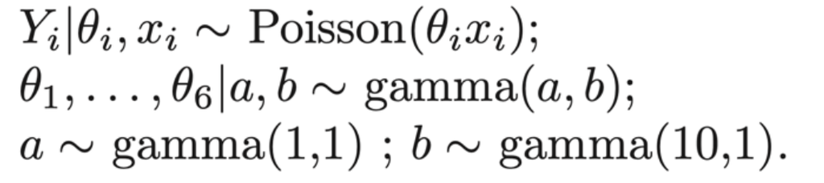

- $Y_i$: the number of occurrences of disease for 6 neighboring counties, therefore, $y_i/x_i$ represents the observed disease rate.
- $\theta_i$: represents the expected disease rate where $E(\theta_i) = a/b$.
- $a$ and $b$ are the parameters of the gamma distribution sampling model of $\theta_i$.

#### Conditional distribution of $p(\theta_1,...,\theta_6|a,b,x,y)$:

$$p(\theta_1,...,\theta_6|a,b,x,y) =
\frac{p(\theta_1,...,\theta_6,y|a,b,x)}{p(y|a,b,x)}$$

- $p(\theta_1, \ldots, \theta_6 | a, b, x, y)$ is the posterior probability distribution of parameters $\theta_1, \ldots, \theta_6$ given $a, b, x,$ and observed data $y$. This is the target we want to estimate, i.e., the distribution of parameters given the observed data and certain conditions.
- $p(\theta_1, \ldots, \theta_6, y | a, b, x)$ is the joint probability distribution of parameters $\theta_1, \ldots, \theta_6$ and observed data $y$ given $a, b, x$.
- $p(y | a, b, x)$ is the marginal probability distribution of observed data $y$ given $a, b, x$. It represents the probability of the observed data, independent of the parameters.

The posterior probability distribution is equal to the joint probability distribution divided by the marginal probability distribution.

#### Therefore, the posterior densities is:

$$\begin{aligned}
p(\theta_1,...,\theta_6,y|a,b,x)
&= p(\theta_1,...,\theta_6|a,b)*p(y|\theta_1,...,\theta_6,x)\\
&= \prod_{i=1}^6\frac{(\theta_ix_i)^{y_i}exp(-\theta_ix_i)}{y_i!}*
\prod_{i=1}^6\frac{(b)^{a}}{\Gamma(a)}\theta_i^{a-1}exp(-b\theta_i)\\
&=f(y)\prod_{i-1}^6 \theta_i^{a+y_i-1}exp(-(b+x_i)\theta_i)\\
&\propto \prod_{i-1}^6 \theta_i^{a+y_i-1}exp(-(b+x_i)\theta_i)
\end{aligned}$$

#### Because $\theta_i$ are conditional independent given a, b, x, y, full conditional distribution of the disease rate for each county is:

$$\begin{aligned}
p(\theta_i|\theta_{-i},a,b,x,y) \propto \prod_{i-1}^6
\theta_i^{a+y_i-1}exp(-(b+x_i)\theta_i) \sim gamma(a+y_i,b+x_i)
\end{aligned}$$

#### Acceptance Ratio

The ratio of the posterior densities comparing a set of **proposal** values $(a^∗, b^∗, \theta)$ to values $(a, b, \theta)$:

$$\begin{aligned}
r
&=\frac{p(\theta_1,...,\theta_6,y|a^*,b^*,x)}{p(\theta_1,...,\theta_6,y|a,b,x)}\\
&=
\prod_{i=1}^{6}\frac{\theta_i^{a^*+y_i-1}exp(-(b^*+x_i)\theta_i)}{\theta_i^{a+y_i-1}exp(-(b+x_i)\theta_i)}\\
&=\prod_{i-1}^6 \theta_i^{a^*-a}exp(-(b^*-b)\theta_i)
\end{aligned}$$

- Note the value of $\theta$, the vector of county-specific rates, is unchanged.

## Metropolis-Hastings Sampling (MCMC sampling)

Run Metropolis-Hastings Algorithm to generate samples of $(a, b, \theta)$ from the posterior, randomly sampling probabilities from uniform distribution to compare with acceptance ratio.

```r
# observed data
x <- c(33, 14, 27, 90, 12, 17)
y <- c(1, 3, 2, 12, 1, 1)
# prior
a <- 1
b <- 10
theta <- rgamma(6, a + y, b + x)
a_delta <- 1
b_delta <- 10
# Define Metropolis-Hastings Algorithm
ratio <- function(a, b, a_new, b_new, theta) {
  prod(theta^(a_new - a) * exp(-(b_new - b) * theta))
}
S <- 10000
set.seed(123)
THETA <- NULL

# Run Metropolis-Hastings Algorithm
for (j in 1:S) {
  if (j%%(S/10) == 0) {
    print(j)
    }
  a_new <- abs(runif(1, a - a_delta, a + a_delta))
  b_new <- abs(runif(1, b - b_delta, b + b_delta))
  r <- ratio(a, b, a_new, b_new, theta) #compute the acceptance ratio
  if (runif(1) < r) {
    # accept
    theta <- rgamma(6, a_new + y, b_new + x)
    THETA <- rbind(THETA, c(a_new, b_new, theta))
    a <- a_new
    b <- b_new
    } else {
      theta <- rgamma(6, a + y, b + x)
      THETA <- rbind(THETA, c(a, b, theta))
    }
}
```

```
## [1] 1000
## [1] 2000
## [1] 3000
## [1] 4000
## [1] 5000
## [1] 6000
## [1] 7000
## [1] 8000
## [1] 9000
## [1] 10000
```

## Posterior inference for disease rates

Compare marginal posterior distributions of $\theta_1, . . . , \theta_6$ with observed $y_1/x_1, . . .,y_6/x_6$

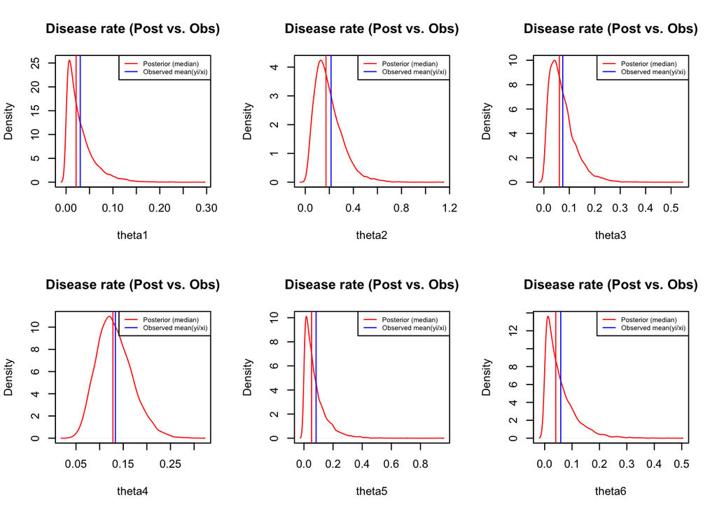

```r
burn_in <- 1000
theta.post <- THETA[, -(1:2)]
y.x <- y/x

par(mfrow = c(2,3))
for (j in 1:6) {
  plot(density(theta.post[,j]), xlab = paste0("theta", j),main = paste0("Disease rate (Post vs. Obs)"),
       col='red')
  abline(v = y.x[j],col = 'blue')
  abline(v = median(theta.post[,j]), col = "red")
  legend('topright', legend=c("Posterior (median)", "Observed mean(yi/xi)"),
       col=c("red", "blue"), lty=1,cex=0.6)

}
```

Based on the plots, each observed average disease rate $y_i/x_i$ is larger than the median value of posterior distribution of $\theta_1,...\theta_6$.

#### Posterior vs. Prior vs. Observed mean (disease rate).

Examine the posterior distribution of $a/b$, and compare it to the corresponding prior distribution as well as to the average of $y_i/x_i$ across the six counties.

$$E(\theta_i) = a/b$$

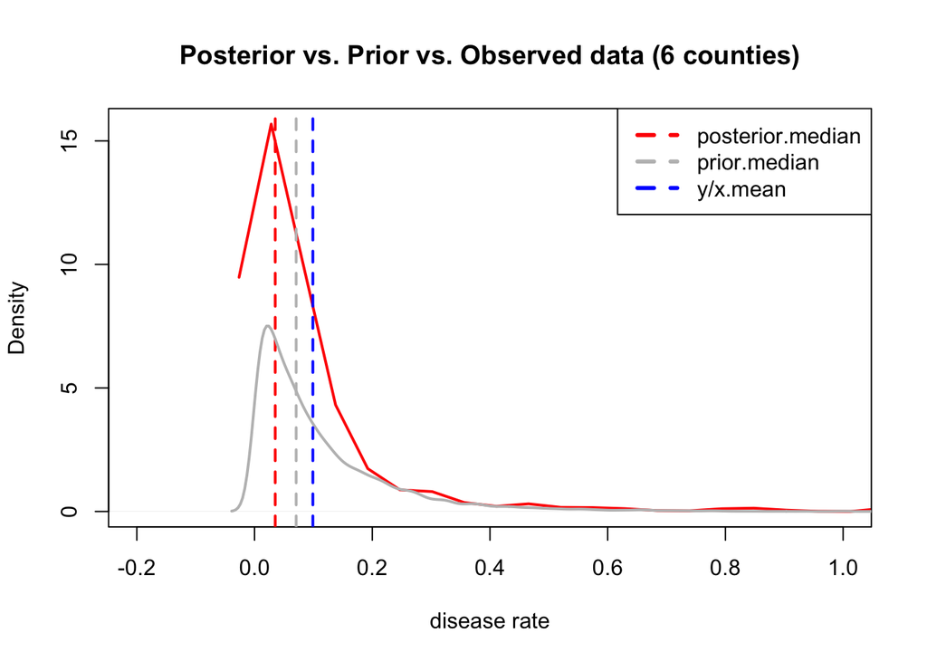

```r
a.b <- THETA[burn_in:S, 1]/THETA[burn_in:S,2]
a.b.prior <- rgamma(S-burn_in + 1, 1, 1)/rgamma(S-burn_in + 1,10, 1)
y.x <- mean(y/x)
# posterior
plot(density(a.b), xlab = "disease rate",main = "Posterior vs. Prior vs. Observed data (6 counties)", col='red',xlim=c(-0.2,1),lwd = 2)
abline(v = median(a.b),col = "red", lwd = 2,lty=2)
# prior
abline(v = median(a.b.prior),col="grey", lwd = 2, lty=2)
lines(density(a.b.prior),col = 'grey',lwd = 2)
# observed
abline(v = y.x, col = "blue", lwd = 2, lty=2)
legend('topright', legend=c("posterior.median", "prior.median","y/x.mean"),
       col=c("red", "grey","blue"), lty=2,cex=1,lwd = 3)
```

Across 6 counties, posterior median disease rate $a/b$ is smaller than prior median $a.prior/b.prior$ and observed average disease rate $y_i/x_i$.

## Investigate higher disease rates of the second county.

Plot samples of $\theta_2$ versus $\theta_j$ for each $j\neq2$, and draw a 45 degree line on the plot as well.

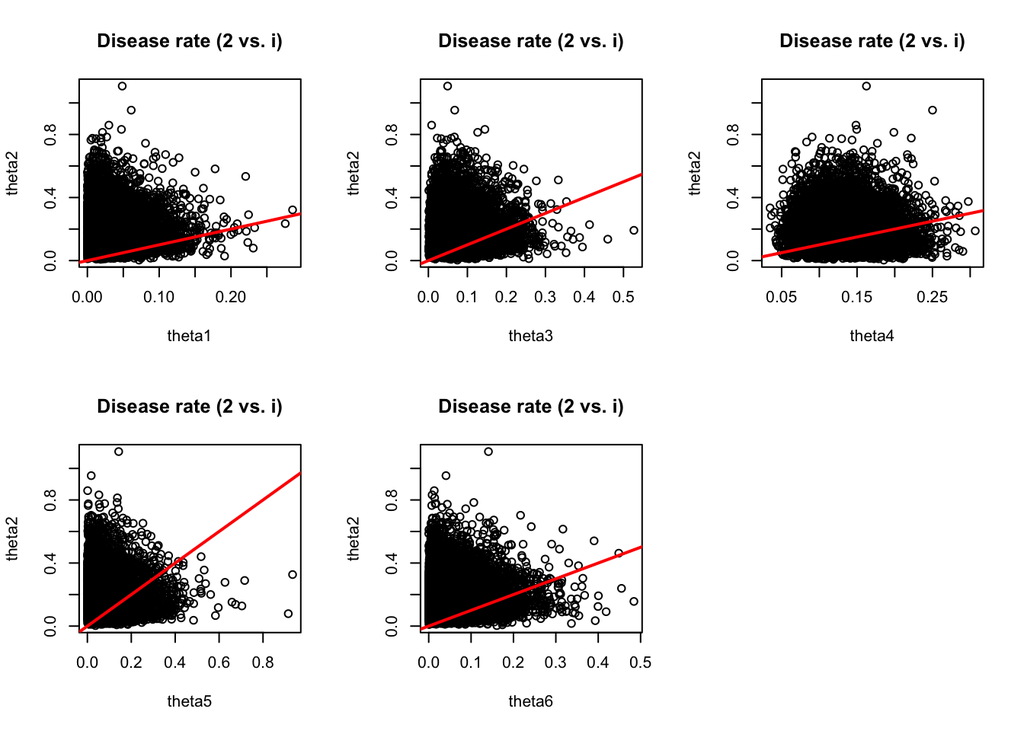

```r
par(mfrow=c(2,3))
for (j in setdiff(1:6, 2)) {
  plot(theta.post[, j], theta.post[, 2], xlab = paste0("theta",j),
       ylab = "theta2", main="Disease rate (2 vs. i)")
  abline(a = 0, b = 1, col = "red", lwd=2)
}
```

#### Estimate $Pr(\theta_2 > \theta_j |x, y)$ for each $j$

$$Pr(\theta_2 > \theta_j |x,
y)$$
:

```r
sapply(setdiff(1:6, 2), function(j) {
  mean(theta.post[, 2] > theta.post[,j])
})
```

```
## [1] 0.9665 0.8697 0.6656 0.8448 0.9030
```

#### Compare $yj/xj$ for each county $j$ vs. Posterior Conclusion ($Pr(\theta_2 = max\{\theta_1, . . . , \theta_6\}|x, y)$. )

```r
mean(theta.post[, 2] == apply(theta.post, 1, max))
```

```
## [1] 0.5783
```

```r
y/x
```

```
## [1] 0.03030303 0.21428571 0.07407407 0.13333333 0.08333333 0.05882353
```

- $Pr(\theta_2 = max\{\theta_1, . . . , \theta_6\}|x, y) = 0.58$.
- $y_2/x_2 = 0.21$: the highest disease rate among six counties in observed data

Observed data shows the second county has the highest disease rate. Also, by **Bayesian analysis**, posterior estimates show that the second county has high probability to be the county with the largest disease rate.